# Predicting Housing Prices for Mecklenberg County, NC - MUSA508 Midterm

## 4.5 Map of residuals for our test:setResiduals Map w/ Moran’s I/plot of the spatial lag in errors

lIn this section, we focus on verifying whether the spatial distribution will have an impact on our model. We mainly use the following approaches:

**residual maps:** It shows the residuals in different places in Mecklenberg County, and we can also observed the distribution of residuals.

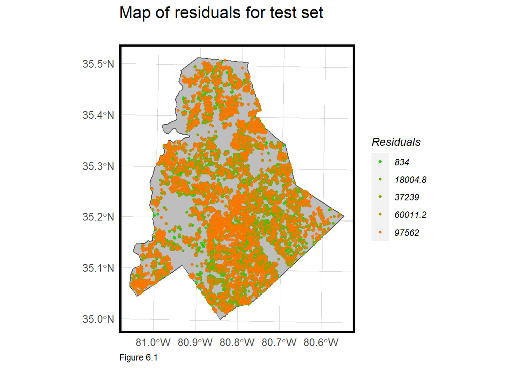

```r
map.res.test <- ggplot() +
  geom_sf(data = st_union(tracts20),fill = 'grey') +
  geom_sf(data = model.test %>%filter(SalePrice.AbsError!= 'NA') ,aes(color = q5(SalePrice.AbsError)), show.legend = "point",size = 1) +
  scale_color_manual(values = palette5,
                     labels = qBr(model.test,'SalePrice.AbsError'),
                     name = "Residuals") +
  labs(title = 'Map of residuals for test set\n',
       caption = 'Figure 6.1') +
  mapTheme() +
  plotTheme()
map.res.test
```

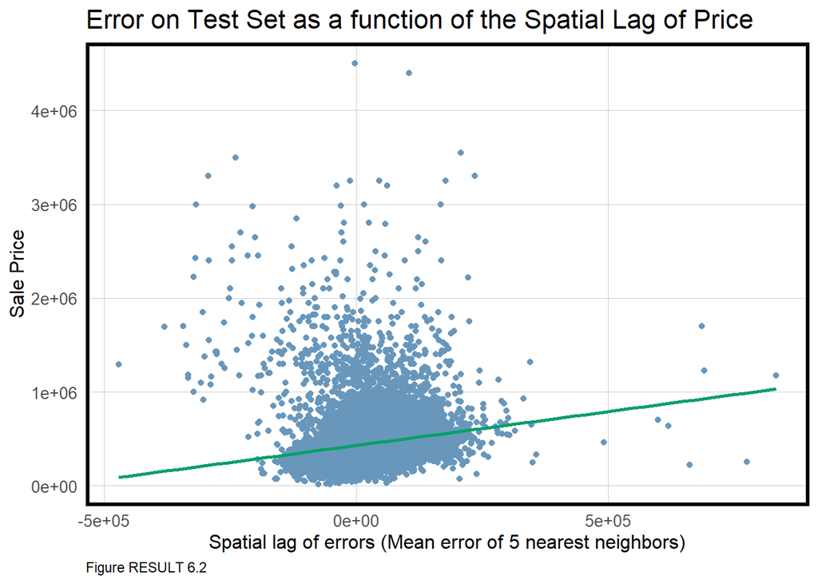

```r
coords <- st_coordinates(all.sf)

neighborList <- knn2nb(knearneigh(coords, 5))

spatialWeights <- nb2listw(neighborList, style="W")

all.sf$lagPrice <- lag.listw(spatialWeights, all.sf$price)

coords.test <-  st_coordinates(model.test)

neighborList.test <- knn2nb(knearneigh(coords.test, 5))

spatialWeights.test <- nb2listw(neighborList.test, style="W")

model.test <- model.test %>%
  mutate(lagPriceError = lag.listw(spatialWeights.test, SalePrice.Error,NAOK =TRUE))

ggplot(model.test, aes(x = lagPriceError, y = price)) +
  geom_point(colour = "#6897BB") +
  geom_smooth(method = "lm", se = FALSE, colour = "#05A167") +
  labs(title = "Error on Test Set as a function of the Spatial Lag of Price",
       caption = "Figure RESULT 6.2",
       x = "Spatial lag of errors (Mean error of 5 nearest neighbors)",
       y = "Sale Price") +
  plotTheme()
```

```r
#morantest
```

**MoranTest:**An approach for measuring spatial autocorrelation. In the picture, the frequency of all 999 randomly permutated I are plotted as a histogram with the Observed I indicated by the orange line. That the observed I is higher then all of the 999 randomly generated, so it provides visual confirmation of spatial autocorrelation.

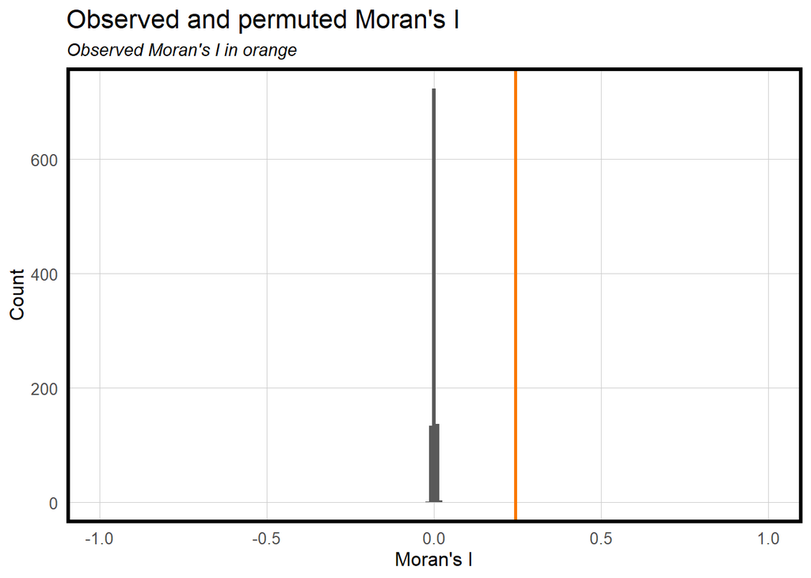

```r
moranTest <- moran.mc(model.test$SalePrice.Error, zero.policy=TRUE, #zero.policy make code runs, but the neighbor is empty
                      spatialWeights.test, nsim = 999,na.action=na.omit)

ggplot(as.data.frame(moranTest$res[c(1:999)]), aes(moranTest$res[c(1:999)])) +
  geom_histogram(binwidth = 0.01) +
  geom_vline(aes(xintercept = moranTest$statistic), colour = "#FA7800",size=1) +
  scale_x_continuous(limits = c(-1, 1)) +
  labs(title="Observed and permuted Moran's I",
       subtitle= "Observed Moran's I in orange",
       x="Moran's I",
       y="Count") +
  plotTheme()
```

## 4.6 Plot predicted prices as a function of observed prices

```r
reg.nhood <- lm(price ~ ., data = as.data.frame(model.training) %>%
                                 dplyr::select(price,age, storyheigh,heatedarea,#prisqft,
                         numfirepla, fullbaths,halfbaths,bedrooms,
                         units,
                         # amenity features
                         police_nn1,police_nn2,police_nn3,school_nn1,
                         school_nn2,school_nn3,church_nn1,church_nn2,
                         church_nn3,park_nn1,park_nn3,firestation_nn2,
                         firestation_nn3,medical_nn2,medical_nn3,
                         #acs
                         pctWhite,pctBachelors,pctPoverty,MedHHInc,
                         Singleadult,Healthins,Familyincome))

model.test.nhood <-
  model.test %>%
  mutate(Regression = "Neighborhood Effects",
         SalePrice.Predict = predict(reg.nhood, model.test),
         SalePrice.Error = SalePrice.Predict- price,
         SalePrice.AbsError = abs(SalePrice.Predict- price),
         SalePrice.APE = (abs(SalePrice.Predict- price)) / price)%>%
  filter(price < 5000000)

model.test <- model.test %>%
  mutate(Regression = "Baseline Regression")

bothRegressions <-
  rbind(
    dplyr::select(model.test, starts_with("SalePrice"), Regression, vfd, price) %>%
      mutate(lagPriceError = lag.listw(spatialWeights.test, SalePrice.Error,NAOK =TRUE)),
    dplyr::select(model.test.nhood, starts_with("SalePrice"), Regression, vfd, price) %>%
      mutate(lagPriceError = lag.listw(spatialWeights.test, SalePrice.Error,NAOK =TRUE)))

st_drop_geometry(bothRegressions) %>%
  gather(Variable, Value, -Regression, -vfd) %>%
  filter(Variable == "SalePrice.AbsError" | Variable == "SalePrice.APE") %>%
  group_by(Regression, Variable) %>%
    summarize(meanValue = mean(Value, na.rm = T)) %>%
    spread(Variable, meanValue) %>%
    kable()
```

| Regression | SalePrice.AbsError | SalePrice.APE |
| --- | --- | --- |
| Baseline Regression | 67696.76 | 0.2694697 |
| Neighborhood Effects | 125118.41 | 0.3317715 |

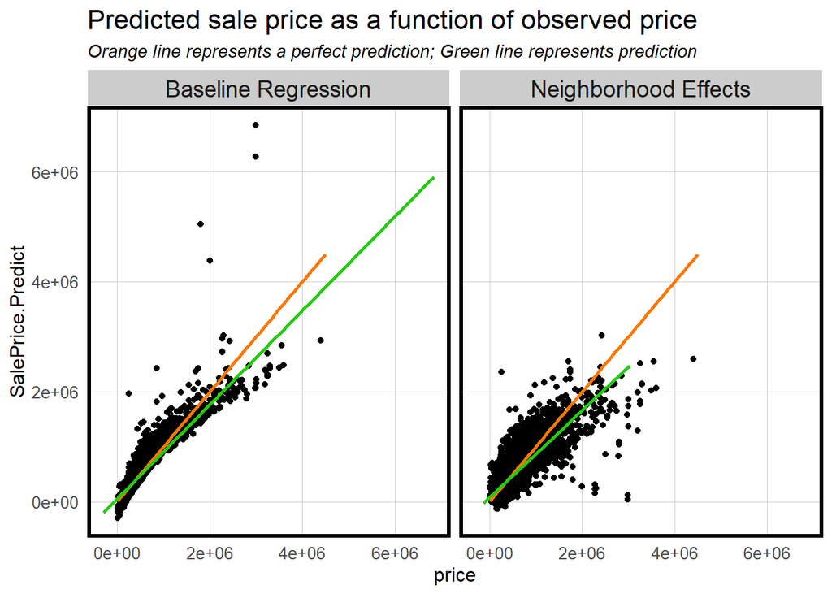

```r
bothRegressions %>%
  dplyr::select(SalePrice.Predict, price, Regression) %>%
    ggplot(aes(price, SalePrice.Predict)) +
  geom_point() +
  stat_smooth(aes(price, price),
             method = "lm", se = FALSE, size = 1, colour="#FA7800") +
  stat_smooth(aes(SalePrice.Predict, price),
              method = "lm", se = FALSE, size = 1, colour="#25CB10") +
  facet_wrap(~Regression) +
  labs(title="Predicted sale price as a function of observed price",
       subtitle="Orange line represents a perfect prediction; Green line represents prediction") +
  plotTheme()
```

## 4.7 map of predicted values for CHALLENGE and entire data set

We filled in the data for the challenge with the modified model.

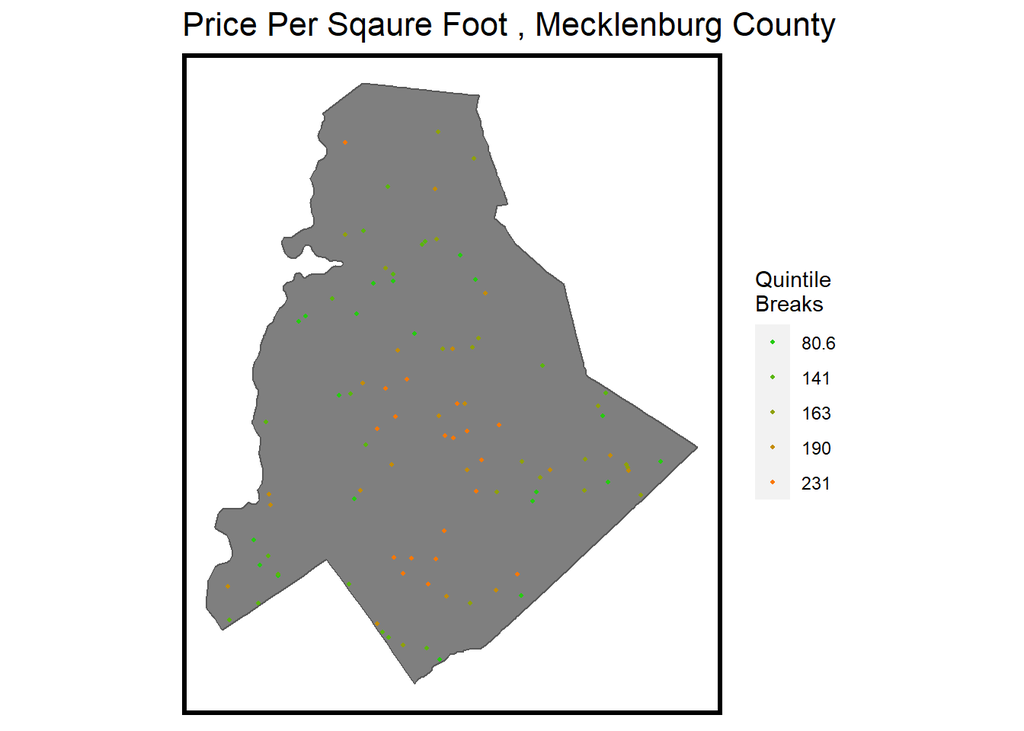

```r
# challenge<- challenge %>%
#   dplyr::select(-price,-prisqft)

testprice <-challenge #%>%filter(prisqft!= 'Inf')
ggplot() +
  geom_sf(data = st_union(tracts20), fill = "grey50") +
  geom_sf(data = testprice%>%filter(prisqft!= 'NA'), aes(colour = q5(prisqft)),
          show.legend = "point", size = .75) +
  scale_colour_manual(values = palette5,
                   labels=qBr(testprice,"prisqft"),
                   name="Quintile\nBreaks") +
  labs(title="Price Per Sqaure Foot , Mecklenburg County") +
  mapTheme()
```

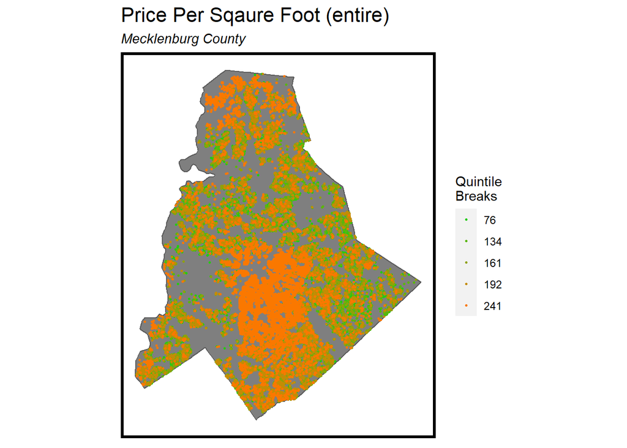

```r
modeling111 <- topredict %>%
  dplyr::select(commonpid,prisqft)

challenge111 <- challenge %>%
  dplyr::select(commonpid,prisqft)

allpricesqft <- rbind(modeling111,challenge111) %>%
  filter(prisqft!= 'NA')


ggplot() +
  geom_sf(data = st_union(tracts20), fill = "grey50") +
  geom_sf(data = allpricesqft, aes(colour = q5(prisqft)),
          show.legend = "point", size = .5) +
  scale_colour_manual(values = palette5,
                   labels=qBr(allpricesqft,"prisqft"),
                   name="Quintile\nBreaks") +
  labs(title="Price Per Sqaure Foot (entire)",subtitle="Mecklenburg County") +
  mapTheme()
```

## 4.8 Map of MAPE by neighborhood

```r
left_join(
  st_drop_geometry(model.test) %>%
    group_by(vfd) %>%
    summarize(meanPrice = mean(price, na.rm = T),
              meanPrediction = mean(SalePrice.Predict, na.rm = T),
            meanMAE = mean(SalePrice.AbsError, na.rm = T),
            meanMAPE = mean(SalePrice.APE, na.rm = T)) ,
    mutate(model.test, predict.fe =
                        predict(lm(price ~ vfd, data = model.test),
                        model.test)) %>%
    st_drop_geometry %>%
    group_by(vfd) %>%
      summarize(meanPrediction = mean(predict.fe))) %>%
      kable() %>% kable_styling()
```

| vfd | meanPrice | meanPrediction | meanMAE | meanMAPE |
| --- | --- | --- | --- | --- |
| Carolina | 351840.3 | 365681.1 | 42812.93 | 0.2110667 |
| Charlotte | 424147.2 | 428015.1 | 65794.23 | 0.2543526 |
| Charlotte Rural | 332920.2 | 321013.3 | 56363.09 | 0.2126259 |
| Cook’s | 385791.7 | 351826.8 | 82903.41 | 0.0004740 |
| Cornelius | 624048.7 | 617531.8 | 79572.01 | 0.6514301 |
| Cornelius Rural | 527500.0 | 590905.0 | 118206.97 | 0.1862289 |
| Davidson | 587246.3 | 604355.7 | 80885.35 | 0.1300826 |
| Davidson Rural | 765058.8 | 711736.9 | 119976.50 | 0.2309773 |
| Hemby Bridge | 448000.0 | 456287.3 | 29568.14 | 0.0628255 |
| Huntersville | 442093.2 | 473562.6 | 73203.90 | 0.1843572 |
| Huntersville Rural | 665235.3 | 663242.1 | 115645.82 | -1.5420211 |
| Idlewild | 276348.5 | 280378.2 | 29753.74 | 0.1197498 |
| Long Creek | 298238.6 | 285984.8 | 45245.10 | 0.2445054 |
| Matthews | 421957.7 | 431926.4 | 61024.72 | 0.2168084 |
| Midland | 340500.0 | 414049.1 | 13049.15 | 0.0315159 |
| Mint Hill | 399338.2 | 417444.1 | 65657.35 | 0.8153683 |
| Mint Hill Rural | 381580.5 | 355958.1 | 76335.50 | 0.3542023 |
| Pineville | 369035.3 | 387666.6 | 47419.69 | 0.0714546 |
| Robinson | 319331.6 | 263131.3 | 72953.90 | 1.0179925 |
| Steele Creek #1 | 397110.0 | 487275.2 | 106506.87 | 0.1493951 |
| Steele Creek #2 | 500462.2 | 550223.7 | 87543.24 | 0.1499737 |
| West Mecklenburg | 350218.5 | 332017.8 | 54543.38 | 0.3702651 |

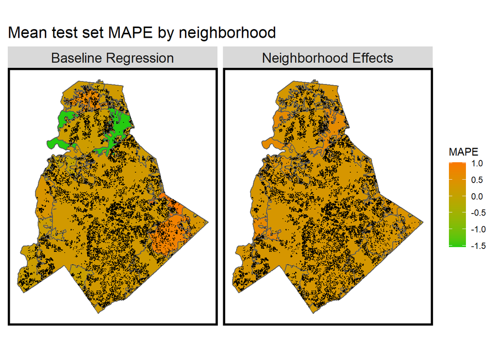

```r
st_drop_geometry(bothRegressions) %>%
  group_by(Regression, vfd) %>%
  summarize(mean.MAPE = mean(SalePrice.APE, na.rm = T)) %>%
  ungroup() %>%
  left_join(nhood.sf) %>%
    st_sf() %>%
    ggplot() +
      geom_sf(aes(fill = mean.MAPE)) +
      geom_sf(data = bothRegressions, colour = "black", size = .05) +
      facet_wrap(~Regression) +
      scale_fill_gradient(low = palette5[1], high = palette5[5],
                          name = "MAPE") +
      labs(title = "Mean test set MAPE by neighborhood") +
      mapTheme()
```

## 4.9 Predicted Map (Test Set)

In this map, we can see that the house price of south Mecklenburg County is relatively high, and most of them are more than $237/squarefeet.

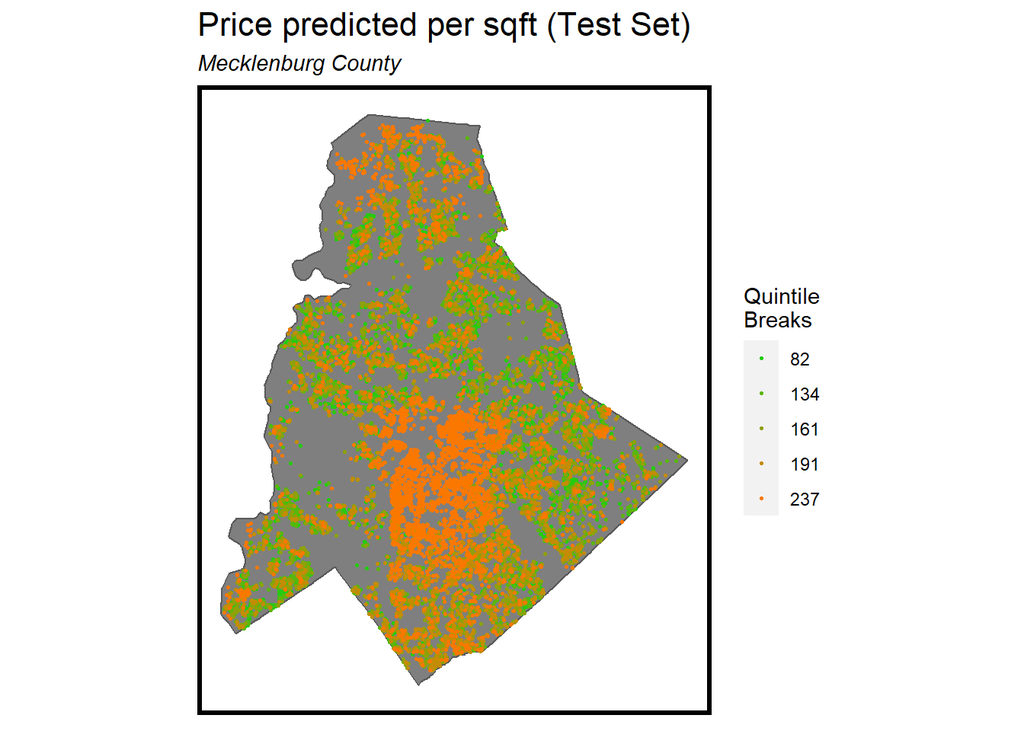

```r
ggplot() +
  geom_sf(data = st_union(tracts20), fill = "grey50") +
  geom_sf(data = model.test, aes(colour = q5(prisqft)),
          show.legend = "point", size = .6) +
  scale_colour_manual(values = palette5,
                   labels=qBr(model.test,"prisqft"),
                   name="Quintile\nBreaks") +
  labs(title="Price predicted per sqft (Test Set)",subtitle="Mecklenburg County") +
  mapTheme()
```

## 4.10 Scatterplot - MAPE by neighborhood mean price

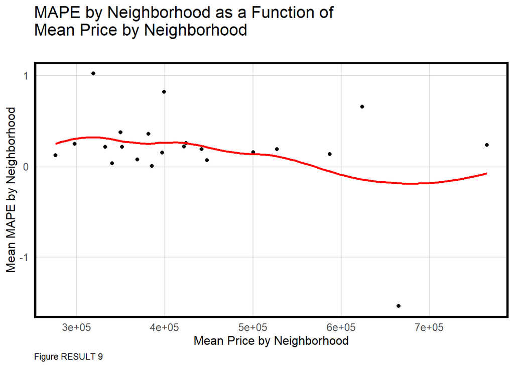

```r
nhood_sum <- model.test %>%
  group_by(vfd) %>%
  summarize(meanPrice = mean(price, na.rm = T),
            meanPrediction = mean(SalePrice.Predict, na.rm = T),
            meanMAE = mean(SalePrice.AbsError, na.rm = T),
            meanMAPE = mean(SalePrice.APE, na.rm = T))
MAPE.nhood.plot <-ggplot()+
  geom_point(data = nhood_sum, aes(x = meanPrice, y = meanMAPE)) +
  stat_smooth(data = nhood_sum, aes(x = meanPrice, y = meanMAPE), method = "loess", se = FALSE, size = 1, colour="red") +
  labs(title = "MAPE by Neighborhood as a Function of\nMean Price by Neighborhood\n",
       caption = 'Figure RESULT 9') +
  xlab('Mean Price by Neighborhood') +
  ylab('Mean MAPE by Neighborhood') +
  plotTheme()



MAPE.nhood.plot
```

## 4.11 Split by Census Groups

In this part, we chose two variables:*race*, *income* and plot them by census tract.

We consider a local white population of more than 50% to be Majority white, and a MedHHInc of more than $32,322 to be High Income. The first map shows that Mecklenburg County is racially divided, with predominantly white neighborhoods to the north and south, which are also where housing prices are higher.

Next, we calculated the Mean absolute percentage error by merging the ACS data with the model2 data. After adding the `Neighborhood Effects` model,from the perspective of ethnicity we can see that there is a significant difference in goodness of fit across the races, the MAPE of the majority non-white baseline is 32%, but that is just 23% for the majority white. This may be determined by the characteristics of the local neighborhood, such as the wide variation in neighborhood housing conditions and lack of consistency; or it may be that ethnic factors play a greater role here.

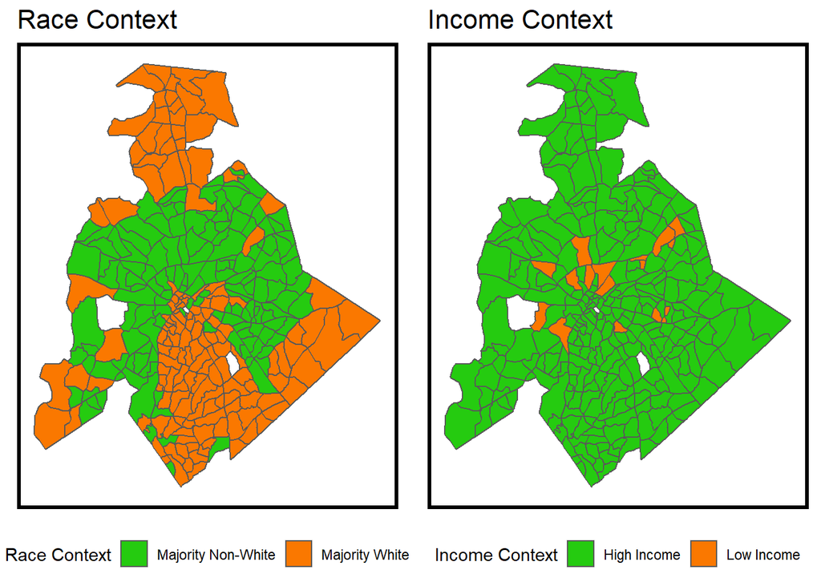

```r
tracts20 <- tracts20 %>%
  mutate(percentWhite = Whites / TotalPop,
         raceContext = ifelse(percentWhite > .5, "Majority White", "Majority Non-White"),
         incomeContext = ifelse(MedHHInc > 32322, "High Income", "Low Income"))

grid.arrange(ncol = 2,
  ggplot() + geom_sf(data = na.omit(tracts20), aes(fill = raceContext)) +
    scale_fill_manual(values = c("#25CB10", "#FA7800"), name="Race Context") +
    labs(title = "Race Context") +
    mapTheme() + theme(legend.position="bottom"),
  ggplot() + geom_sf(data = na.omit(tracts20), aes(fill = incomeContext)) +
    scale_fill_manual(values = c("#25CB10", "#FA7800"), name="Income Context") +
    labs(title = "Income Context") +
    mapTheme() + theme(legend.position="bottom"))
```

```r
st_join(bothRegressions, tracts20) %>%
  group_by(Regression, raceContext) %>%
  summarize(mean.MAPE = scales::percent(mean(SalePrice.APE, na.rm = T))) %>%
  st_drop_geometry() %>%
  spread(raceContext, mean.MAPE) %>%
  kable(caption = "Test set MAPE by neighborhood racial context")
```

Test set MAPE by neighborhood racial context

| Regression | Majority Non-White | Majority White |
| --- | --- | --- |
| Baseline Regression | 32% | 23% |
| Neighborhood Effects | 37% | 30% |

```r
st_join(bothRegressions, tracts20) %>%
  filter(!is.na(incomeContext)) %>%
  group_by(Regression, incomeContext) %>%
  summarize(mean.MAPE = scales::percent(mean(SalePrice.APE, na.rm = T))) %>%
  st_drop_geometry() %>%
  spread(incomeContext, mean.MAPE) %>%
  kable(caption = "Test set MAPE by neighborhood income context")
```

Test set MAPE by neighborhood income context

| Regression | High Income | Low Income |
| --- | --- | --- |
| Baseline Regression | 27% | 10% |
| Neighborhood Effects | 33% | 51% |